# Relatório Rede StaffWatch

Equipe Staff Watch

2024-12-09

## Introdução

Neste relatório, analisamos dados de rede coletados ao longo da última semana. O objetivo é entender como melhorar ou manter o **desempenho de rede** para garantir estabilidade ao call center.

## Conectando ao Banco de Dados

Primeiro, carregamos os pacotes necessários para realizar a análise e estabelecemos uma conexão com o banco de dados MySQL para consultar os dados necessários. O código a seguir conecta-se ao banco de dados `StaffWatch` e obtém os dados de captura.

Estabelecendo conexão e verificando se os dados vieram de forma correta

```
##   idCaptura captura         dataCaptura                       modelo
## 1         1       1 2024-12-09 11:23:58 Armazenamento total: 7.75 GB
## 2         2       8 2024-12-09 11:23:58 Armazenamento total: 7.75 GB
## 3         3      15 2024-12-09 11:23:58 Armazenamento total: 7.75 GB
## 4         4       6 2024-12-09 11:23:58                        loop1
## 5         5      47 2024-12-09 11:23:58                        loop1
## 6         6      12 2024-12-09 11:23:58                        loop1
##   fkComponente fkComputador fkAuxComponente
## 1            2            4               6
## 2            2            4               7
## 3            2            4               8
## 4            3            4               9
## 5            3            4              10
## 6            3            4              11
```

## Filtrando os dados de rede

Neste momento, filtramos os dados do banco de acordo com a rede para iniciar a análise.

```r
# Análises por componente
pacotesEnv <- capturaGeral[capturaGeral$fkAuxComponente == 2, ]
pacotesReceb <- capturaGeral[capturaGeral$fkAuxComponente == 3, ]
latencia <- capturaGeral[capturaGeral$fkAuxComponente == 20, ]
perdaPacotes <- capturaGeral[capturaGeral$fkAuxComponente == 21, ]
tempoFalha <- capturaGeral[capturaGeral$fkAuxComponente == 26, ]
```

## Médias e Alertas dos dados

### 1.Média dos dados de rede nos últimos 7 dias

A média dos dados de rede é relevante pois indicam tendências e padrões gerais, podendo ser usadas para monitorar e diagnosticar a saúde da infraestrutura de rede.

```r
# Média de cada métrica
mediaPacotesEnv <- mean(pacotesEnv$captura)
mediaPacotesReceb <- mean(pacotesReceb$captura)
mediaLatencia <- mean(latencia$captura)
mediaPerdaPacotes <- mean(perdaPacotes$captura)


print(paste("Valor médio de pacotes enviados(qtd):", mediaPacotesEnv))
```

```
## [1] "Valor médio de pacotes enviados(qtd): 292.6"
```

```r
print(paste("Valor médio de pacotes recebidos(qtd):", mediaPacotesReceb))
```

```
## [1] "Valor médio de pacotes recebidos(qtd): 817"
```

```r
print(paste("Valor médio de pacotes perdidos(%):", mediaPerdaPacotes))
```

```
## [1] "Valor médio de pacotes perdidos(%): 0"
```

```r
print(paste("Valor médio da latência(Ms):", mediaLatencia))
```

```
## [1] "Valor médio da latência(Ms): 3.6"
```

### 2.Alertas de cada métrica - Quantidade de vezes que foi exibido um alerta.

Entender a quantidade de dados que ocasionaram em alertas, ouseja, passaram do limite de estabilidade é de suma importância para tomar decisões a respeito da estabilidade da rede. Muitos alertas em pouco tempo podem indicar problemas relevantes.

```r
picosLatencia <- latencia$captura[latencia$captura >= 100]
picosPerdaPacotes <- perdaPacotes$captura[perdaPacotes$captura >= 1]
picosTempoFalha <- tempoFalha$captura[tempoFalha$captura >= 350]

tamanhoPicosLatencia <- length(picosLatencia)
tamanhoPicosPerdaPacotes <- length(picosPerdaPacotes)
tamanhoPicosTempoFalha <- length(picosTempoFalha)

print(paste("Quantidade de alertas de latência(Ms):", tamanhoPicosLatencia))
```

```
## [1] "Quantidade de alertas de latência(Ms): 0"
```

```r
print(paste("Quantidade de alertas de tempo entre falhas(minutos):", tamanhoPicosTempoFalha))
```

```
## [1] "Quantidade de alertas de tempo entre falhas(minutos): 0"
```

```r
print(paste("Quantidade de alertas de pacotes perdidos(%):", tamanhoPicosPerdaPacotes))
```

```
## [1] "Quantidade de alertas de pacotes perdidos(%): 0"
```

```
## [1] "Não houveram picos de latência na última semana."
```

```
## [1] "Não houveram picos de perda de pacotes."
```

```
## [1] "Não houveram picos de tempo de falha."
```

## Correlação entre Latência de Rede e Métricas de Desempenho (Uso de CPU, Pacotes Enviados e Pacotes Perdidos)

Este estudo visa exibir a correlação entre a latência de rede e outras métricas de desempenho da infraestrutura de TI, como o uso de CPU, pacotes enviados e pacotes perdidos, para entender como esses fatores influenciam a **qualidade da rede**. A latência de rede, que é o tempo que os pacotes levam para viajar de um ponto a outro na rede, pode ser impactada por diversos elementos da rede e da infraestrutura.

- **Latência de Rede vs Uso de CPU:** O uso elevado de CPU pode indicar sobrecarga no servidor ou dispositivo de rede, o que pode resultar em uma latência maior devido ao processamento excessivo de pacotes ou solicitações.
- **Latência de Rede vs Pacotes Enviados:** O aumento no número de pacotes enviados pode gerar congestionamento de tráfego, aumentando a latência, já que mais pacotes precisam ser processados e transmitidos pela rede.
- **Latência de Rede vs Pacotes Perdidos:** Pacotes perdidos indicam problemas na transmissão, como falhas de rede ou congestionamento. Esse tipo de perda afeta diretamente a latência, pois os pacotes precisam ser retransmitidos, aumentando o tempo total de entrega.

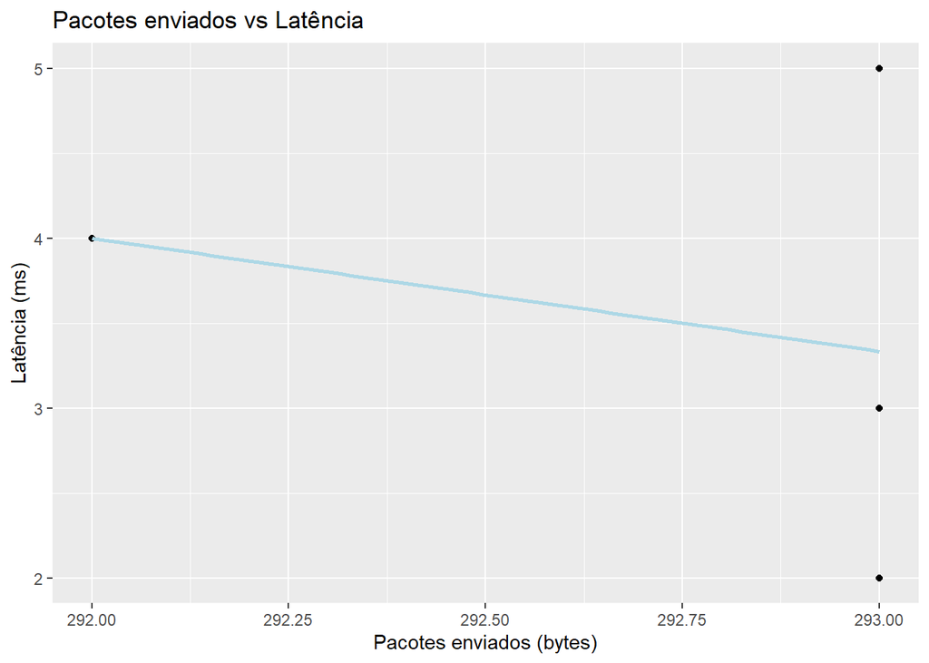

```
## [1] "Uso de CPU e latência possuem tamanhos diferentes e não podem ser correlacionados."
```

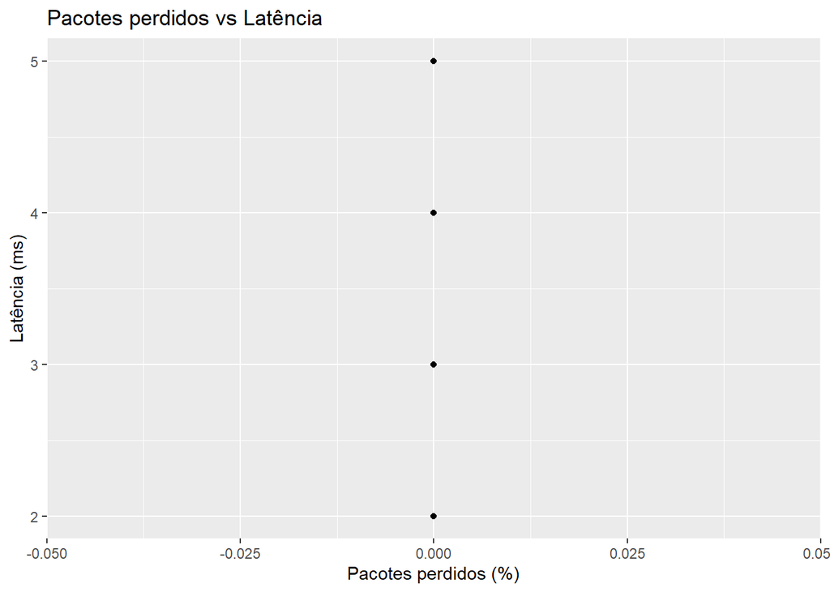

## Fechando a Conexão com o Banco de Dados

Ao final da análise, encerramos a conexão com o banco de dados.

```r
# Fechar a conexão com o banco de dados
dbDisconnect(con)
```

```
## [1] TRUE
```